# Should you forfeit in League of Legends?

Joshua Schmucki

## Introduction

League of Legends is a world-renowned free-to-play MOBA (Multiplayer Online Battle Arena) game developed by RIOT Games. Since its release in 2009, League of Legends has garnered over 100 million users and has been a driving force in bringing esports into the limelight of entertainment.

The game pits two teams of five players against each other in an effort to destroy the other team's base. The standard League of Legends map has each team's base on the opposite side of the map. Each player on a team is given a specific role which binds them to a certain area of the map called a lane. The two bases are connected via these lanes. Each lane has turrets which must be destroyed in order to get closer to the enemy's base. Each team sends their players to their respective lanes where the players will fight near the centerline of the map in their areas for gold and other resources. Picking your fights wisely and coordinating with your team will allow you to overpower your opponents and attack their towers/buildings for a short time. If you and your team continue to fight and farm resources wisely, you will eventually push closer to the enemy's base and destroy it for the win

There are many factors that contribute to a team's ability to win such as team synergy, team composition, advantages won by purchasing items with gold, etc. However, just as there are ways for a team or a player to get ahead in a game, there are methods in place for a team in a disadvantageous state to come back into a winning situation.

-Players can buy items with gold that is won by killing enemy minions (small, easy-to-kill ai soldiers that constantly push against the enemy base), towers (combat structures which fire at any hostile entity), or champions (enemy players). Items then give combat advantage through stat bonuses. Getting more/better items than your lane opponent will generally get you ahead of them.

-Besides enemy minions and enemy players, there are neutral monsters that can give a large cahce of gold, or even a buff for the player that defeats it. There are also Epic neutral monsters which usually require the combined efforts of a few team members to take down, but once defeated, they give powerful buffs to the team that defeats them. These monsters are **dragons** of different kinds or the biggest monster called **Baron Nashor**.

-Even if an opponent is much stronger than you, multiple teammates can gang up on that opponent. Doing this can even be beneficial, as players who find themselves in a strong position are automatically given a bounty which is paid out to the player that kills them. This gives the killing player a monetary boost, and disadvantage to the bountied player as their lane can be attacked with little risk to the attackers while the bountied player is respawning. It does wonders to even out a game.

## Problem Statement

As I mentioned, there are many factors that play into a team's ability to win that change constantly throughout the game, and an early advantage will not always correlate to a later win. However, I have noticed a toxic trait among a growing number of players. As soon as there is any disadvantage for their team, however slight, some players will immediately announce to the rest of the team that the game is a lost cause, and that the entire team should give up. They may even sometimes use the enemy team's advantage to justify throwing the game by intentionally killing themselves (which gives gold to the enemy) or by quitting the game altogether (which puts the game in a 4 v 5 situation and is basically unwinnable for the 4). In essence, they would rather quickly get this game over and go onto another one instead of putting in any effort to come back from a slight disadvantage.

## My Goal

My goal is to observe how some common conditions that players use to justify throwing or quitting affect the final outcome of the game. As a bonus, I will be teaching the principles and steps of **the Data Science Pipeline** along the way.

However, before I begin, I am using RIOT's api, which necessitates putting this disclaimer somewhere in the beginning: *Joshua Schmucki's Final Project isn't endorsed by Riot Games and doesn't reflect the views or opinions of Riot Games or anyone officially involved in producing or managing Riot Games properties. Riot Games, and all associated properties are trademarks or registered trademarks of Riot Games, Inc.*

*If you don't care about how I got the data and you just want to see the results click here*

## Step 1: Data Scraping

Here, you can find the libraries necessary for this notebook

```python
import pandas as pd
import numpy as np
import requests
from bs4 import BeautifulSoup
import json
import os
import time
import random
import matplotlib.pyplot as plt
import scipy.optimize as scip
import math
map_size = 16000
debugging = False
```

```python
apikey = "RGAPI-22bc0b85-0138-4e63-8bae-9d4317777900"
```

```python
#These are just status variables that I used to keep track of the number of requests that I sent to
#Riot's API
number_of_requests = 0
number_of_waits = 0
```

The first step is to get information regarding a user's account. In the game and the client, players refer to each other via their summoner name. However, this is rarely how the Riot Database indexes or queries information on users. Thankfully, there is a method in the [The API](https://developer.riotgames.com/apis#summoner-v4/GET_getBySummonerName) to get account info from a player's summoner name. Checking the api documentation, we can see that we form a query to the Riot database with a specific URL in the form

`https://na1.api.riotgames.com/lol/summoner/v4/summoners/by-name/[SUMMONER NAME HERE]?api_key=[API KEY HERE]`

Let's run this using my summoner name: Schmuckinatør

```python
s_name ='Schmuckinatør'
r = requests.get("https://na1.api.riotgames.com/lol/summoner/v4/summoners/by-name/" + s_name + "?api_key=" + apikey)
soup = BeautifulSoup(r.text,'html.parser')
me = json.loads(soup.text)
me
```

```
{'id': 'o4ANwUxKcDGcx_6ETttEA_WuoOihLGSSfo74B3BNW2QQtFA',
 'accountId': 'wpHW-qretuHgSl3ohDwS9fYJRMy3Sl5K-dRHvn6_LFH6lGw',
 'puuid': 'dXMmFOZA0Tfk2Jqv7RluFInAtVMo9ocuMHiLYfhfioI0zKHh8f7IZYQT1DR8Lq1ithLtUgEhKLKVUQ',
 'name': 'Schmuckinatør',
 'profileIconId': 7,
 'revisionDate': 1620967472000,
 'summonerLevel': 248}
```

Sure enough, I can tell this is my account based on the level and the name it returned. You can see other fields associated with my account. The most important one is the puuid, which a lot of other Riot API methods use to get data about an account. Let's write a function to quickly acquire the puuid or account id from a summoner name

```python
def get_puuid_from_summoner(s_name):
    global number_of_requests
    global number_of_waits
    number_of_requests += 1
    while True:
        r = requests.get("https://na1.api.riotgames.com/lol/summoner/v4/summoners/by-name/" + s_name + "?api_key=" + apikey)
        if(r.status_code == 429):
            time.sleep(5)
            number_of_waits += 1
        else:
            break
    soup = BeautifulSoup(r.text,'html.parser')
    me = json.loads(soup.text)
    return me['puuid']
```

```python
def get_accid_from_summoner(s_name):
    global number_of_requests
    global number_of_waits
    number_of_requests += 1
    while True:
        r = requests.get("https://na1.api.riotgames.com/lol/summoner/v4/summoners/by-name/" + s_name + "?api_key=" + apikey)
        if(r.status_code == 429):
            time.sleep(5)
            number_of_waits += 1
        else:
            break
    soup = BeautifulSoup(r.text,'html.parser')
    me = json.loads(soup.text)
    return me['accountId']
```

```python
def get_summoner_from_puuid(puuid):
    global number_of_requests
    global number_of_waits
    number_of_requests += 1
    while True:
        r = requests.get('https://na1.api.riotgames.com/lol/summoner/v4/summoners/by-puuid/' + puuid + '?api_key=' + apikey)
        if(r.status_code == 429):
            time.sleep(5)
            number_of_waits += 1
        else:
            break
    soup = BeautifulSoup(r.text,'html.parser')
    me = json.loads(soup.text)
    return me['name']
```

**Note**: all functions that query the Riot database have to be aware of the limit on the API key. Using the developer API key, queries can only

- Request 20 times per second for a total of:
- 100 Requests every 2 minutes

After you send a query, if you get a response code of 429, this indicates that you have gone over the rate limit for the api key. If we get this code, we will want to wait a little bit before sending another request

It's great to have a user ID from the database, but we need game data to analyze! Back to the [API](https://developer.riotgames.com/apis#match-v5)! Here we can see that there is a method which gets a list of matches from a puuid, which we have!

`https://americas.api.riotgames.com/lol/match/v5/matches/by-puuid/[PUUID]/ids?start=[START INDEX]&count=[NO. OF RESULTS]&api_key=[API KEY]`

Here it is in use

```python
s_name ='Schmuckinatør'
puuid = get_puuid_from_summoner(s_name)
start = '0'
count = '10'
r = requests.get("https://americas.api.riotgames.com/lol/match/v5/matches/by-puuid/" + puuid + "/ids?start="+ str(start) + "&count=" + str(count) + "&api_key=" + apikey)
soup = BeautifulSoup(r.text,'html.parser')
games = json.loads(soup.text)
games
```

```
['NA1_3906032792',
 'NA1_3905967884',
 'NA1_3904759082',
 'NA1_3904751519',
 'NA1_3904734731',
 'NA1_3904679821',
 'NA1_3904567134',
 'NA1_3904570347',
 'NA1_3904517865',
 'NA1_3904418534']
```

Great! We're almost there. These are match Ids, which identify games, but don't tell us too much about the games themselves. Nonetheless, we should write a function to get a list of games from a puuid so we can do this later

```python
def get_game_ids_from_puuid(puuid, start = 0, count = 10):
    global number_of_requests
    global number_of_waits
    number_of_requests += 1
    while True:
        r = requests.get("https://americas.api.riotgames.com/lol/match/v5/matches/by-puuid/" + puuid + "/ids?start="+ str(start) + "&count=" + str(count) + "&api_key=" + apikey)
        if(r.status_code == 429):
            time.sleep(5)
            number_of_waits += 1
        else:
            break
    soup=BeautifulSoup(r.text,'html.parser')
    games = json.loads(soup.text)
    return games
```

Now! To find game data from the game Id's, we must again go back to the [API](https://developer.riotgames.com/apis#match-v5/GET_getMatch). Here is a standard format for getting match data.

`https://americas.api.riotgames.com/lol/match/v5/matches/[MATCH ID]?api_key=[API KEY]`

Let's see what kind of data this gets us. We will be using our 'games' list we generated earlier

```python
match_id = games[0]
r = requests.get("https://americas.api.riotgames.com/lol/match/v5/matches/" + match_id + "?api_key=" + apikey)
soup = BeautifulSoup(r.text,'html.parser')
match_data = json.loads(soup.text)
```

match_data is the json object returned. It's too long to show here, but it includes a field called 'metadata' which I'll show, and then a list of participant data. I will show one participant, but just know there are 10 of these (1 for each player)

```python
match_data['metadata']
```

```
{'dataVersion': '2',
 'matchId': 'NA1_3906032792',
 'participants': ['VRMcfm3xHJKIGdyI-e6ys2Qig97AYVDiu9sEYT6Wz6Pm0nBTsdOJB8ZRt9dpZg6zz5QDWo36GHw1zQ',
  'e0BvBG9PbPjjBXgXRJFrGoje1oReGF4vWoagNme_t85tPV-_vuHQo1hZP8_9fOa1sibmtWrRZwEKNQ',
  'rf4Bgf59JlhdiYzRB3AUffY8KMdc-p5AGcT21sfZujGJqXO_dApK5GqCdnTOX_yYgUgyzAZn1xaqFw',
  'm38gnLd6TB90hYC01NVZ3mgi09aI2niX8--e9S4WV5dwEBpGPYwc0HiqYROIXiP-wmZlMU9OjM4z1A',
  'b0vMufjI226tXTTWISTYqxkvQB4NBeCCZIRIGa1aqE4LwKcudC32Ugd7iTRar2vd0mzj1mdvJQxTPA',
  'beQicQdYIfqutqC40zhdMe8W-yzU5lQXzIhoFUmGOzgv-MYLMSmlW6Ib4M0pZc6tI_7_PkQGh06X-g',
  'dXMmFOZA0Tfk2Jqv7RluFInAtVMo9ocuMHiLYfhfioI0zKHh8f7IZYQT1DR8Lq1ithLtUgEhKLKVUQ',
  'L6fwE0edHR7o88VFAIZLkonbXKgOQ4z1rFliKEGPhWXag0UHTOx4alkqFbaLiruu5d1BWxIe8E7hGw',
  'w9wOhI_BtY_ibK6xkfocJ2xJFjXT8BZDeoZZgLwrStqi9utolFHiTLwZkhnmD2QhW3R9xKEtmDuH7w',
  'IJFBcr6BbjFlJI-Qkkz2o93Xho2xe831JDo3mj4mzsupZYBoBxlN6RAB8rSO6dqcYHn79O6K24i5sw']}
```

```python
match_data['info']['participants'][0]
```

```
{'assists': 14,
 'baronKills': 0,
 'bountyLevel': 3,
 'champExperience': 22919,
 'champLevel': 18,
 'championId': 10,
 'championName': 'Kayle',
 'championTransform': 0,
 'consumablesPurchased': 8,
 'damageDealtToBuildings': 9648,
 'damageDealtToObjectives': 32497,
 'damageDealtToTurrets': 9648,
 'damageSelfMitigated': 36609,
 'deaths': 7,
 'detectorWardsPlaced': 5,
 'doubleKills': 2,
 'dragonKills': 1,
 'firstBloodAssist': False,
 'firstBloodKill': False,
 'firstTowerAssist': False,
 'firstTowerKill': True,
 'gameEndedInEarlySurrender': False,
 'gameEndedInSurrender': False,
 'goldEarned': 20323,
 'goldSpent': 20375,
 'individualPosition': 'TOP',
 'inhibitorKills': 1,
 'inhibitorsLost': 0,
 'item0': 3042,
 'item1': 4633,
 'item2': 3153,
 'item3': 3006,
 'item4': 3115,
 'item5': 3100,
 'item6': 3340,
 'itemsPurchased': 22,
 'killingSprees': 3,
 'kills': 11,
 'lane': 'TOP',
 'largestCriticalStrike': 0,
```

[output cut: 57 more lines]

```
 'totalTimeCCDealt': 396,
 'totalTimeSpentDead': 319,
 'totalUnitsHealed': 5,
 'tripleKills': 1,
 'trueDamageDealt': 21348,
 'trueDamageDealtToChampions': 3413,
 'trueDamageTaken': 1115,
 'turretKills': 4,
 'turretsLost': 4,
 'unrealKills': 0,
 'visionScore': 50,
 'visionWardsBoughtInGame': 5,
 'wardsKilled': 8,
 'wardsPlaced': 17,
 'win': True}
```

Holy cow, that's a lot of data. This is a much bigger data return than anything else we've looked at so far. You are looking at summary statistics for the game that we entered. This would be information you could see in the post-game lobby scoreboard. In the 'metadata' object, there is a list of participants which is the puuid of every player in the game, and in the 'info' object, there is another participants array which has objects whose index corresponds to the user in the metadata list. These info participant objects are statistics for that particular player. Later on, we will organize this data dump so that it is much easier to look at and get rid of any extraneous metadata. Let's write another function to get this match summary from a match Id.

```python
def get_match_data(match_id):
    global number_of_requests
    global number_of_waits
    number_of_requests += 1
    while True:
        r = requests.get("https://americas.api.riotgames.com/lol/match/v5/matches/" + match_id + "?api_key=" + apikey)
        if(r.status_code == 429):
            time.sleep(5)
            number_of_waits += 1
        else:
            break
    soup = BeautifulSoup(r.text,'html.parser')
    match_data = json.loads(soup.text)
    return match_data
```

The last thing we need to analyze the state of a game at any point during the game. Luckily, on the same [API](https://developer.riotgames.com/apis#match-v5/GET_getTimeline) page there is a query to get a match timeline from the Riot database:

`https://americas.api.riotgames.com/lol/match/v5/matches/[MATCH ID]/timeline?api_key=[API KEY]`

```python
match_id = games[0]
r = requests.get("https://americas.api.riotgames.com/lol/match/v5/matches/" + match_id + "/timeline?api_key=" + apikey)
soup = BeautifulSoup(r.text,'html.parser')
timeline = json.loads(soup.text)
```

Again, this timeline is too huge to show on this project. I will show the metadata included, and a single frame, but just be aware that there are a huge number of frames!

```python
timeline['metadata']
```

```
{'dataVersion': '2',
 'matchId': 'NA1_3906032792',
 'participants': ['VRMcfm3xHJKIGdyI-e6ys2Qig97AYVDiu9sEYT6Wz6Pm0nBTsdOJB8ZRt9dpZg6zz5QDWo36GHw1zQ',
  'e0BvBG9PbPjjBXgXRJFrGoje1oReGF4vWoagNme_t85tPV-_vuHQo1hZP8_9fOa1sibmtWrRZwEKNQ',
  'rf4Bgf59JlhdiYzRB3AUffY8KMdc-p5AGcT21sfZujGJqXO_dApK5GqCdnTOX_yYgUgyzAZn1xaqFw',
  'm38gnLd6TB90hYC01NVZ3mgi09aI2niX8--e9S4WV5dwEBpGPYwc0HiqYROIXiP-wmZlMU9OjM4z1A',
  'b0vMufjI226tXTTWISTYqxkvQB4NBeCCZIRIGa1aqE4LwKcudC32Ugd7iTRar2vd0mzj1mdvJQxTPA',
  'beQicQdYIfqutqC40zhdMe8W-yzU5lQXzIhoFUmGOzgv-MYLMSmlW6Ib4M0pZc6tI_7_PkQGh06X-g',
  'dXMmFOZA0Tfk2Jqv7RluFInAtVMo9ocuMHiLYfhfioI0zKHh8f7IZYQT1DR8Lq1ithLtUgEhKLKVUQ',
  'L6fwE0edHR7o88VFAIZLkonbXKgOQ4z1rFliKEGPhWXag0UHTOx4alkqFbaLiruu5d1BWxIe8E7hGw',
  'w9wOhI_BtY_ibK6xkfocJ2xJFjXT8BZDeoZZgLwrStqi9utolFHiTLwZkhnmD2QhW3R9xKEtmDuH7w',
  'IJFBcr6BbjFlJI-Qkkz2o93Xho2xe831JDo3mj4mzsupZYBoBxlN6RAB8rSO6dqcYHn79O6K24i5sw']}
```

```python
# Number of frames!!!!!
len(timeline['info']['frames'])
```

```
43
```

```python
print('frame: 1')
print('event 1')
print(timeline['info']['frames'][1]['events'][0])
print('number of events: ' + str(len(timeline['info']['frames'][1]['events'])))
print('participant frame 1')
print(timeline['info']['frames'][1]['participantFrames']['1'])
print('number of participant frames: ' + str(len(timeline['info']['frames'][1]['participantFrames'])))
```

```
frame: 1
event 1
{'levelUpType': 'NORMAL', 'participantId': 6, 'skillSlot': 1, 'timestamp': 2733, 'type': 'SKILL_LEVEL_UP'}
number of events: 37
participant frame 1
{'championStats': {'abilityHaste': 0, 'abilityPower': 0, 'armor': 32, 'armorPen': 0, 'armorPenPercent': 0, 'attackDamage': 55, 'attackSpeed': 113, 'bonusArmorPenPercent': 0, 'bonusMagicPenPercent': 0, 'ccReduction': 0, 'cooldownReduction': 0, 'health': 600, 'healthMax': 600, 'healthRegen': 10, 'life…
number of participant frames: 10
```

This is even more data than before! This result is a list of 'frames' from the game. A frame is a period of about 60 seconds where events are captured and catalogued. At the beginning of each frame, each player's instantaneous statistics are captured as well. This will be extremely useful for us to examine the game state over time. Let's write another function to retrieve the timeline from a match given a match Id

```python
def get_match_timeline(match_id):
    global number_of_requests
    global number_of_waits
    number_of_requests += 1
    while True:
        r = requests.get("https://americas.api.riotgames.com/lol/match/v5/matches/" + match_id + "/timeline?api_key=" + apikey)
        if(r.status_code == 429):
            time.sleep(5)
            number_of_waits += 1
        else:
            break
    soup = BeautifulSoup(r.text,'html.parser')
    timeline = json.loads(soup.text)
    return timeline
```

The last bit of scraping we need to do involves retrieving assets for the game. If you look through the timeline, you will see events that pertain to items (buying, selling, undoing, destroying). The name of the item is not stored with the frame, only the number. That number refers to some databases which store information about each item or champion etc. given a numeric Id. Here, I am retrieving those databases and writing functions to get a champion name and an item name given their numeric Id.

```python
r = requests.get("http://ddragon.leagueoflegends.com/cdn/11.10.1/data/en_US/champion.json")
soup = BeautifulSoup(r.text,'html.parser')
champs = json.loads(soup.text)
champion_id_dictionary = {}
for c in champs['data']:
    champion_id_dictionary[int(champs['data'][c]['key'])] = c
def get_champion(id):
    return champion_id_dictionary[id]
```

```python
r = requests.get("http://ddragon.leagueoflegends.com/cdn/11.10.1/data/en_US/item.json")
soup = BeautifulSoup(r.text,'html.parser')
items = json.loads(soup.text)
item_id_dictionary = {}
for i in items['data']:
    item_id_dictionary[i] = items['data'][str(i)]['name']
def get_item(id):
    return item_id_dictionary[str(id)]
```

## Tidying data

This is the process of taking the raw data you retrieve and make it look more presentable/readable. First implemented is a short helper function that takes an integer number of milliseconds and converts it into a string with the format (mm:ss). Most timestamps are stored as a number of milliseconds since the start of the match, so having this will help time readability

```python
def ms_string(i):
    m = int((i/1000)/60)
    s = int(i/1000) - (m*60)
    return str(m) + ":" + str(s).zfill(2)
```

### Structure

I found it was easiest to keep track of game data by making classes for the different components of each game.

#### Participant

A single player in a game. Specifies the players database id (puuid), champion they played this game (champ), numeric id in the game's data (num), which lane this player was in (lane), whether this player won their game, and the player's in-game name (summoner_name).

```python
class Participant:
    def __init__(self, puuid, champ, num, lane, team, won, summoner_name):
        self.puuid = puuid
        self.champ = champ
        self.num = num
        self.lane = lane
        self.team = team
        self.won = won
        self.summoner_name = summoner_name
        self.has_myth = False
    def __str__(self):
        return ("Summoner Name: " + self.summoner_name + "\nChamp: " + self.champ + "\nLane: " + self.lane)
```

#### Team

Simply a list of players(Participants) and whether this team won or not

```python
class Team:
    def __init__(self):
        self.participants = []
        self.won = False
    def add(self, participant):
        self.participants.append(participant)
        self.won = participant.won
    def lookup_champ(self, n):
        for p in self.participants:
            if(p.num == n):
                return p.champ
        return 'Champ Not Found'
    def lookup_lane(self, n):
        for p in self.participants:
            if(p.num == n):
                return p.lane
        return 'Champ Not Found'
    def __str__(self):
        ret = ""
        for p in self.participants:
            ret += p.lane + ": " + p.champ + " (" + p.summoner_name + ")\n"
        if(self.won):
            ret += "Winning Team\n"
        else:
            ret += "Losing Team\n"
        return ret
```

#### Game

On the highest level there is a game. A game has

-2 teams (red and blue team) with

-5 participants(players) on each team.

-Match data (cumulative stats for each player after the game has finished) and a

-Timeline (a timeline of events that happen in game).

Players are numbered 1-10 in the match and timeline data (which a player object stores), so in order to find a player's information, a game has a **boolean array specifying if the player number is on the red or blue team.** Then, that team can be searched for the desired player number.

A game can also be easily identified by it's duration(length).

A game can lookup a champion name or a player's name based on the player's integer number from the match or timeline data. It can also lookup which team a player is on based on that same integer number

Finally, later on, a game's timeline will be parsed for important events and stored in a dataframe (**TDF**)

```python
class Game:
    def __init__(self, match_data, timeline):
        self.timeline = timeline
        self.match_data = match_data
        self.blue_team = Team()
        self.red_team = Team()
        self.part_on_blue = [pd.NA]
        self.length = ms_string(match_data['info']['gameDuration'])

    def add_participant(self, participant):

        if(participant.team == 100):
            self.part_on_blue.append(True)
            self.blue_team.add(participant)
        else:
            self.part_on_blue.append(False)
            self.red_team.add(participant)
    def lookup_champ(self, n):
        if n == 0:
            return 'minion'
        elif self.part_on_blue[n]:
            return self.blue_team.lookup_champ(n)
        else:
            return self.red_team.lookup_champ(n)
    def lookup_lane(self, n):
        if self.part_on_blue[n]:
            return self.blue_team.lookup_lane(n)
        else:
            return self.red_team.lookup_lane(n)
    def lookup_team(self, n):
        if self.part_on_blue[n]:
            return "Blue Team"
        return "Red Team"
    def get_new_puuid(self, pid):
        for p in self.red_team.participants:
            if(p.puuid == pid):
                return self.blue_team.participants[random.randrange(0,5)].puuid
        return self.red_team.participants[random.randrange(0,5)].puuid
    def summoner_lookup_puuid(self, puuid):
        for p in self.red_team.participants:
            if(p.puuid == puuid):
                return p.summoner_name
        for p in self.blue_team.participants:
            if(p.puuid == puuid):
                return p.summoner_name
        return(pd.NA)
    def lookup_summoner(self, summ_name):
        for p in self.red_team.participants:
            if(p.summoner_name == summ_name):
                return True
        for p in self.blue_team.participants:
            if(p.summoner_name == summ_name):
                return True
        return false
    def __repr__(self):
        ret = "Game() " + self.length
        if(self.blue_team.won):
            ret += " Blue Victory"
        else:
            ret += " Red Victory"
        return ret
    def __str__(self):
        return "Red Team:\n" + str(self.red_team) + "------------\nBlue Team:\n" + str(self.blue_team)
```

### Tidying Timeline Data

The first data we will sort through is a match's timeline. The raw timeline is a long, unreadable json object with a lot of extraneous metadata. I had to decide what events to extract from the timeline object based on how important they were to the outcome of the game.

The mission of this project is to find events that a player can perceive about the enemy team that would lead them to conclude that a game is 'too far gone to win'. Based on that, I decided to only track player events that an enemy player can see.

This would exclude things like

- when a player upgrades an ability (which a player can only see about themselves)
- when a player places a ward (which a player cannot possibly consider during the game)

I also excluded events that don't contribute to either team or that can be inferred from other events.

- **'PAUSE_END'** (this marks when the players can take control of their characters in the very first second they load into the game)
- **'ITEM_DESTROYED/SOLD'** (You don't really care what items an enemy used to have, only the items they currently have. Also, when you construct a certain item that is comprised of other items combined, there will be a 'item_purchased' event for the resulting item and destroying the base items. You only really need to know that they now have the resulting item)

Events I have included from the timeline are ones such as

- **CHAMPION_KILL** (gives the killer a monetary advantage)
- **BUILDING_KILL** (gives the entire team a small monetary advantage)
- **ITEM_PURCHASED** (gives the buyer a stat advantage)
- **ELITE_MONSTER_KILL** (gives the entire team a stat advantage)

Below is code which takes a complete Game object and filters the game's timeline object for desired events. Eventually, it will add a new field to the Game object to store a dataframe of events, which will be much more readable

```python
def process_timeline(g):
    event = [] #These are all different fields I am tracking for every event. At the end, these lists will become columns
    mstime = [] #in the resulting dataframe
    realtime = []
    desc = []
    playernum = []
    victimnum = []
    assist = []
    champ = []
    team = []
    lane = []

    #here, we are going to look through every frame in the game's timeline and record events that may be important to the
    #outcome of the game
    for f in g.timeline['info']['frames']:
        ev = f['events']
        for e in ev:
            typ = e['type']
            #These are the codes for different events to be excluded
            if((typ == 'ITEM_DESTROYED') | (typ == 'SKILL_LEVEL_UP') | (typ == 'PAUSE_END') | (typ == 'WARD_PLACED') | (typ == 'WARD_KILL') | (typ == 'GAME_END') | (typ == 'ITEM_SOLD') | (typ == 'ITEM_UNDO') | (typ == 'CHAMPION_TRANSFORM')):
                continue
            #These are certain fields that all events have and we can record right away by adding them to our lists
            event.append(typ)
            mstime.append(e['timestamp'])
            realtime.append(ms_string(e['timestamp']))

            ##Beyond this point, we are trying to fill the rest of the columns with values from the event in question.
            ##However, some events have unique fields that other events don't have, or the fields are stored in a different
            ##format. This is my attempt at synthesizing all the different types of eventdata fields into a similar format
            ## so events can be compared
            if(typ == 'PAUSE_END'):
                playernum.append(pd.NA)
            elif((typ == 'CHAMPION_KILL') | (typ == 'CHAMPION_SPECIAL_KILL') | (typ == 'TURRET_PLATE_DESTROYED') | (typ == 'BUILDING_KILL') | (typ == 'ELITE_MONSTER_KILL')):
                playernum.append(e['killerId'])
                champ.append(g.lookup_champ(e['killerId']))
                if(e['killerId'] == 0):
                    x = e['position']['x']
                    y = e['position']['y']
                    lane.append("see_desc")
                    if(y < map_size - x):
                        team.append("Blue Team")
                    else:
                        team.append("Red Team")
                else:
                    team.append(g.lookup_team(e['killerId']))
                    lane.append(g.lookup_lane(e['killerId']))

            elif((typ == 'SKILL_LEVEL_UP') | (typ == 'ITEM_PURCHASED') | (typ == 'LEVEL_UP')):
                playernum.append(e['participantId'])
                champ.append(g.lookup_champ(e['participantId']))
                lane.append(g.lookup_lane(e['participantId']))
                team.append(g.lookup_team(e['participantId']))
            elif(typ == 'DRAGON_SOUL_GIVEN'):
                playernum.append(-1)
                champ.append(pd.NA)
                lane.append(pd.NA)
                if(e['teamId'] == 100):
                    team.append("Blue Team")
                else:
                    team.append("Red Team")
            else:
                playernum.append("?")

            if(typ == 'PAUSE_END'):
                desc.append(pd.NA)
                victimnum.append(pd.NA)
            elif typ == 'SKILL_LEVEL_UP':
                desc.append("Skill Slot " + str(e['skillSlot']))
                victimnum.append(e['skillSlot'])
            elif typ == 'ITEM_PURCHASED':
                desc.append(get_item(e['itemId']) + " Purchased")
                victimnum.append(e['itemId'])
            elif typ == 'LEVEL_UP':
                desc.append('Level up to ' + str(e['level']))
                victimnum.append(e['level'])
            elif typ == 'CHAMPION_KILL':
                victimnum.append(e['victimId'])
                desc.append(str(e['killerId']) + " kills " + str(e['victimId']))
            elif typ == 'CHAMPION_SPECIAL_KILL':
                ret = e['killType']
                if(e['killType'] == 'KILL_MULTI'):
                    ret += " (" + str(e['multiKillLength']) + ")"
                desc.append(ret)
                victimnum.append(pd.NA)
            elif typ == 'TURRET_PLATE_DESTROYED':
                desc.append(str(e['killerId']) + ' destroys ' + e['laneType'] + ' turret plating')
                victimnum.append(e['laneType'])
            elif typ == 'ELITE_MONSTER_KILL':
                if(e['killerTeamId'] == 100):
                    ret = 'blue'
                else:
                    ret = 'red'
                desc.append(ret + ' team kills ' + e['monsterType'])
                victimnum.append(e['monsterType'])
            elif typ == 'BUILDING_KILL':
                ret = e['buildingType'] + " destroyed in " + e['laneType']
                if e['buildingType'] == 'TOWER_BUILDING':
                    ret = e['towerType'] + " " + ret
                desc.append(ret)
                victimnum.append(e['buildingType'])
            elif typ == 'DRAGON_SOUL_GIVEN':
                desc.append(e['name'])
                victimnum.append(e['teamId'])
            else:
                desc.append("UNKNOWN EVENT")
                victimnum.append(pd.NA)
            try:
                assist.append(e['assistingParticipantIds'])
            except(KeyError):
                assist.append([])
    ##Here is the creation of the dataframe we were looking to make
    df = pd.DataFrame({'Event_Code' : event,
                       'ms_time' : mstime,
                       'in_game_time': realtime,
                       'Event_Description' : desc,
                       'Event_Actor' : playernum,
                       'Actor_Champ' : champ,
                       'Actor_Lane' : lane,
                       'Actor_Team' : team,
                       'Event_Subject' : victimnum,
                       'Assisters' : assist})
    g.tdf = df
```

Now we need to make Game objects and all their subsidiary objects. This function will take a list of game Ids and create a new game object for each game Id. This function will also create team objects and fill them with participant objects which will be filled by information from the match data. In the end, it will return a list of complete Game objects.

Note that this function can be used to blindly process all the games in the gamelist, or it can be used to specifically find ranked games(explained later) in the game list and return those.

- ranked - a boolean specifying whether or not to search for a ranked game
- n - desired number of games to process from the gamelist
- namelist - a list of names. Skip processing the game if any person in this list was a participant in the game

If I am looking specifically for ranked games, this method will skip processing any other match type except for ranked games. Other factors are used to weed certain games out. These are more thorougly described later in the data analysis section of the notebook

```python
def process_gamelist(gamelist, ranked, n, namelist):
    no_games = 0
    matches = []
    for g in gamelist:
        ##Here, if we have reached the desired number of games processed, we will end the loop
        if((no_games == n) & ranked):
            break
        ##This is a function we made earlier to retrieve the match data from the API
        gd = get_match_data(g)
        ##This tests if the game was successfully retrieved. If the request to the API failed, the resulting game data
        ##Will not have an 'info' field. If a request fails for whatever reason, we will skip processing this game
        try:
            test = gd['info']
        except(KeyError):
            if debugging:
                print('bad_request')
            continue
        ##In the Information stored about a game, there is a field that specifies what kind of game the player queued up for
        ##A queue ID of 420 indicates that the game was a Ranked soloqueue 5v5 game (I promise I'm not making this up)
        if(ranked & (gd['info']['queueId'] != 420)):
            if debugging:
                print('not_ranked')
            continue
        ##Because of the nature of the analysis I want to do, I will skip processing a game if it was surrendered before it
        ##ended naturally
        if((gd['info']['participants'][0]['gameEndedInEarlySurrender'] | gd['info']['participants'][0]['gameEndedInSurrender']) & ranked):
            if debugging:
                print('surrendered')
            continue
        ##Here I am checking if any member of the current game was part of a previous game that I've analyzed. If so, skip
        ##this game and go to the next one
        used = False
        if(ranked):
            for part in gd['info']['participants']:
                if part['summonerName'] in namelist:
                    if debugging:
                        print("used")
                    used = True
                    break
        if used:
            continue
        ##Here, I have accepted the game as valid according to the factors above, and am creating the Game object along with
        ##information about everyone who played in it
        gt = get_match_timeline(g)
        game = Game(match_data = gd, timeline = gt)
        p_list = game.match_data['metadata']['participants']
        i = 1
        for p in p_list:
            c = game.match_data['info']['participants'][i-1]['championName']
            l = game.match_data['info']['participants'][i-1]['teamPosition']
            t = game.match_data['info']['participants'][i-1]['teamId']
            w = game.match_data['info']['participants'][i-1]['win']
            s = game.match_data['info']['participants'][i-1]['summonerName']
            part = Participant(puuid=p, num=i, champ=c, lane=l, team=t, won=w, summoner_name=s)
            game.add_participant(part)
            i = i+1
        process_timeline(game)
        matches.append(game)
        no_games += 1
    return matches
```

Now lets put it all together. We will take a summoner name, feed it into the pipeline, and get a list of complete game objects from the user's match history.

```python
summoner_name = "Doublelift"
cur_puuid = get_puuid_from_summoner(summoner_name)
game_list = get_game_ids_from_puuid(cur_puuid)
gl = process_gamelist(game_list,False, 0, [])
for g in gl:
    process_timeline(g)
```

gl is a list of complete game objects with processed timelines. Let us look at one game's timeline for important events

```python
gl[0].tdf
```

|  | Event_Code | ms_time | in_game_time | Event_Description | Event_Actor | Actor_Champ | Actor_Lane | Actor_Team | Event_Subject | Assisters |
| --- | --- | --- | --- | --- | --- | --- | --- | --- | --- | --- |
| 0 | ITEM_PURCHASED | 3281 | 0:03 | Doran's Blade Purchased | 6 | Sett | TOP | Red Team | 1055 | [] |
| 1 | ITEM_PURCHASED | 3281 | 0:03 | Health Potion Purchased | 6 | Sett | TOP | Red Team | 2003 | [] |
| 2 | ITEM_PURCHASED | 3446 | 0:03 | Doran's Blade Purchased | 4 | Jinx | BOTTOM | Blue Team | 1055 | [] |
| 3 | ITEM_PURCHASED | 4008 | 0:04 | Doran's Blade Purchased | 9 | Caitlyn | BOTTOM | Red Team | 1055 | [] |
| 4 | ITEM_PURCHASED | 4008 | 0:04 | Health Potion Purchased | 9 | Caitlyn | BOTTOM | Red Team | 2003 | [] |
| ... | ... | ... | ... | ... | ... | ... | ... | ... | ... | ... |
| 267 | ITEM_PURCHASED | 930806 | 15:30 | Phage Purchased | 1 | Renekton | TOP | Blue Team | 3044 | [] |
| 268 | LEVEL_UP | 944545 | 15:44 | Level up to 11 | 6 | Sett | TOP | Red Team | 11 | [] |
| 269 | ITEM_PURCHASED | 947155 | 15:47 | Control Ward Purchased | 2 | JarvanIV | JUNGLE | Blue Team | 2055 | [] |
| 270 | LEVEL_UP | 955180 | 15:55 | Level up to 11 | 7 | Zac | JUNGLE | Red Team | 11 | [] |
| 271 | LEVEL_UP | 955444 | 15:55 | Level up to 10 | 1 | Renekton | TOP | Blue Team | 10 | [] |

272 rows × 10 columns

This is much better! We can actually see events and their contents at a glance. Now is a good time to explain the structure of the timeline dataFrame. Keep in mind that a row corresponds to one event.

- **Event_Code** - Code that identifies different kinds of events. Useful when trying to find effects based on types of events
- **ms_time** - milliseconds since the start of the game. Acts as a timestamp for the event
- **in_game_time** - (mm::ss) format of ms_time. Useful for visualizing timestamps, not for comparison
- **Event_Description** - My best effort to describe the event in english based on the event's metadata
- **Event_Actor** - The number for the player who was the primary actor in the event
- **Actor_Champ** - The champion played by the primary actor
- **Actor_Lane** - The lane position of the primary actor
- **Actor_Team** - The team that the primary actor is a part of, or the team that benefits from the event
- **Event_Subject** - The item or player which the primary actor does the event to. In the case of events such as ITEM_PURCHASED, this is the numeric ID of the item bought. However, in events like CHAMPION_KILL, this column represents the player that was killed by the primary actor. For events which don't necessarily have a victim, this column is filled with NA
- **Assisters** - Applicable to events which can have more than one player contributing to the completion of the event (CHAMPION_KILL, ELITE_MONSTER_KILL). Assisting in an event can sometimes have implications for the rest of the game.

## Exploratory Data Analysis

Now that we have a way to acquire and parse data, we just have to amass some games to analyze and then look at how well the justifications of the discouraged players hold up.

**Some factors that we have to consider before doing analysis**:

I would like to pull a sample of 500 games to start. This will give us a wide range of games/events to choose from. I want to make this as random as possible. If I pull 500 games from the same player, that player may have faults intrinsic to their playstyle that are responsible for a winstreak/losestreak. This, I anticipate, will be hard to account for in an analysis. To minimize this effect, I will take 5 games from different players. I will start with a single name, get 5 games from that profile, then choose 1 random game and select 1 random user from the other team to sample the next 5 games. Choosing someone from the enemy team will guarantee that I don't choose the same user twice or a friend of that user (which may lead to analyzing the same matches twice if a user plays with their friends a lot).

Another stipulation is that I must take is that the matches I analyze must be ranked. I can assume (for the most part) that players will try their hardest in ranked games, resulting in 'typical' gameplay with 'typical' outcomes. People will tend to experiment with champions or strategies they are unexperienced with in non-ranked gamemodes, which can skew an outcome

Another Stipulation is that I will be polling from games around the skill level of the initial person I am polling. If you want to get 500 games from around gold/silver, make sure the first name entered corresponds to a gold/silver player. The same goes for any other rank.

Another stipulation is that I will be excluding games where either team voted to surrender early. If a team didn't let the game play out to fruition, then we cannot know if the winning team won because the game was truly lost for the surrendering team, or if a player perceived that the game was lost and threw in the towel. We need to observe the results of full games so that we can zero in on the early factors that truly influence the end game

Finally, I will only be looking at events within the first 20 minutes of a game. The goal of this analysis is to find early signs of a game 'too far gone' and should be worth surrendering. 20 minutes includes the first forefeit window at 15 minutes (which requires a unanimous vote on behalf of the team) and the normal forefeit window after 20 minutes (which requires only 4/5 players to surrender). In other words, this timeframe only includes factors that discouraged players see before forefeiting.

```python
##This function is used to find the next user to analyze. They are randomly selected from the list of games(g)
def choose_next_puuid(gs, old_pid):
    i = random.randrange(0,len(gs))
    g = gs[i]
    return g.get_new_puuid(old_pid)
```

```python
master_list = []
s_name = 'Schmuckinatør'
cur_puuid = get_puuid_from_summoner(s_name)
used_names = []
iter_count = 0
while(len(master_list)<500):
    if iter_count%5 == 0:
        print(str(len(master_list)) + '/500')
    iter_count += 1
    game_list = get_game_ids_from_puuid(cur_puuid, start = 0, count = 100)
    gl = process_gamelist(game_list, True, 5, used_names)
    for g in gl:
        process_timeline(g)
        master_list.append(g)
    if(len(gl)==0):
        used_names.append(get_summoner_from_puuid(cur_puuid))
        gl = process_gamelist(game_list[0:5],False, 0, [])
        cur_puuid = choose_next_puuid(gl, cur_puiid)
        continue
    used_names.append(g.summoner_lookup_puuid(cur_puuid))
    cur_puuid = choose_next_puuid(gl, cur_puuid)
```

```
0/500
25/500
50/500
75/500
100/500
125/500
150/500
175/500
200/500
225/500
250/500
275/500
300/500
325/500
350/500
375/500
394/500
412/500
437/500
462/500
487/500
```

```python
len(master_list)
```

```
502
```

And just like that, we have at least 500 games that match our criteria. Now to start crunching numbers. We will compile a list of common conditions that players call early surrender justifications, then query the list of games to see if those conditions truly result in a loss.

### First Blood

Some players are ready to throw in the towel as soon as the enemy team gets first blood. This will be an easy first test, as we just count up the number of teams that got first blood AND won and divide it by the total number of games.

```python
first_blood_wins = 0
for gam in master_list:
    a = gam.tdf
    b = a[(a['Event_Code'] == 'CHAMPION_SPECIAL_KILL') & (a['Event_Description'] == 'KILL_FIRST_BLOOD')]
    fb = b.iloc[0]['Actor_Team']
    if(fb == 'Red Team'):
        w = gam.red_team.won
    else:
        w = gam.blue_team.won
    if(w):
        first_blood_wins += 1
first_blood_wins / len(master_list)
```

```
0.5657370517928287
```

As it turns out, the team who gets first blood often has an above average expected winrate. However, I don't think it's enough of a split to definitively count the game as lost

### First Dragon

Another point where people are ready to call it quits is when the enemy team gets the first dragon, which supplies a small stat buff to the team that kills it. Let's do a similar analysis.

We will have to change one thing. Some games, a dragon is never defeated in the duration of the game. To account for this, we must count the number of games where no dragon is defeated and subtract it from the total amount of games we are polling from, as a game with no dragons defeated doesn't contribute to the winrate of winning/losing games **with** a dragon defeated in them

```python
first_dragon_wins = 0
no_drags = 0
for gam in master_list:
    a = gam.tdf
    b = a[(a['Event_Code'] == 'ELITE_MONSTER_KILL') & (a['Event_Subject'] == 'DRAGON')]
    try:
        fd = b.iloc[0]['Actor_Team']
        if(fd == 'Red Team'):
            w = gam.red_team.won
        else:
            w = gam.blue_team.won
        if(w):
            first_dragon_wins += 1
    except(IndexError):
        no_drags += 1
first_dragon_wins / (len(master_list) - no_drags)
```

```
0.5836653386454184
```

I am going to continue the same type of simple analysis for other "First" events. The outputs of each of these functions is a decimal ranging from 0-1 which represents the chance that a team with the specified condition will eventually win the game

### First Tower

```python
first_tower_wins = 0
no_towers = 0
for gam in master_list:
    a = gam.tdf
    b = a[(a['Event_Code'] == 'BUILDING_KILL') & (a['Event_Subject'] == 'TOWER_BUILDING')]
    try:
        ft = b.iloc[0]['Actor_Team']
        if(ft == 'Red Team'):
            w = gam.red_team.won
        else:
            w = gam.blue_team.won
        if(w):
            first_tower_wins += 1
    except(IndexError):
        no_towers += 1
first_tower_wins / (len(master_list) - no_towers)
```

```
0.6115537848605578
```

### First Herald

```python
first_herald_wins = 0
no_heralds = 0
for gam in master_list:
    a = gam.tdf
    b = a[(a['Event_Code'] == 'ELITE_MONSTER_KILL') & (a['Event_Subject'] == 'RIFTHERALD')]
    try:
        fh = b.iloc[0]['Actor_Team']
        if(fh == 'Red Team'):
            w = gam.red_team.won
        else:
            w = gam.blue_team.won
        if(w):
            first_herald_wins += 1
    except(IndexError):
        no_heralds += 1
        continue
first_herald_wins / (len(master_list) - no_heralds)
```

```
0.6095617529880478
```

### First Baron

Baron is an epic monster which gives the team who kills it a huge advantage, as it gives the whole team a stat buff as well as empowers their minions. Whichever team gets the first Baron should have a huge advantage.

```python
first_baron_wins = 0
no_barons = 0
for gam in master_list:
    a = gam.tdf
    b = a[(a['Event_Code'] == 'ELITE_MONSTER_KILL') & (a['Event_Subject'] == 'BARON_NASHOR')]
    try:
        fb = b.iloc[0]['Actor_Team']
        if(fb == 'Red Team'):
            w = gam.red_team.won
        else:
            w = gam.blue_team.won
        if(w):
            first_baron_wins += 1
    except(IndexError):
        no_barons += 1
        continue
first_baron_wins / (len(master_list) - no_barons)
```

```
0.8359788359788359
```

### First Mythic Item

This is a bit of an interesting query. Mythic items are special items which are, themselves, strong, but they also boost the efficacy of all your other items. However, each player can only have one. Normally, a player will try to purchase this item as soon as possible before their other items. Will the team with the first Mythic Item win out?

```python
#Items are stored by their Id number in the event list. In order to discover which item is being bought/sold, we must
#look it up in the asset database and check it's description to find out if the item bought was mythic or not
def is_item_mythic(lst):
    ret = []
    for i in lst:
        ret.append('Mythic Passive' in items['data'][str(i)]['description'])
    return ret
```

```python
first_mythic_wins = 0
no_mythics = 0
for gam in master_list:
    a = gam.tdf
    b = a[(a['Event_Code'] == 'ITEM_PURCHASED')]
    try:
        c = b[is_item_mythic(b['Event_Subject'])]
        fm = c.iloc[0]['Actor_Team']
        if(fm == 'Red Team'):
            w = gam.red_team.won
        else:
            w = gam.blue_team.won
        if(w):
            first_mythic_wins += 1
    except(IndexError):
        no_mythics += 1
        continue
first_mythic_wins / (len(master_list) - no_mythics)
```

```
0.6155378486055777
```

### Kill difference at 20 mins

Now, just doing a simple games_where_this_happens/total_games winrate analysis is somewhat simple. However, league games and their interactions tend to be more complex. First blood can just be an unfortunate accident and don't always reflect the strength of a team over time. Let's take a look at winrate based on the kill difference between the two teams at 20 minutes (around the time where teams look to surrender if at all).

First, lets look at a distribution of games and the winner's kill counts at 20 minutes. This may help inform a winrate graph by showing the sample size for games with a certain kill difference (winning team's kills - losing team's kills). We should expect to see that in most games, the team that eventually wins should have more kills than the team that eventually loses. If both teams are evenly matched (as in randomly made, rank-based matchmaking), then most games should be pretty close in kill count throughout the game. Whenever a team gets ahead in kills (and by extension gold) they will tend to win the game. In other words, you won't expect many games where the winning team has a really high kill difference if the teams are mostly evenly matched, and you wont expect the winning team to be behind in kills at the mid game.However, there will be instances where the team that eventually wins will be behind at 20 mins. This will be shown by a negative kill difference.

```
<function matplotlib.pyplot.show(close=None, block=None)>
```

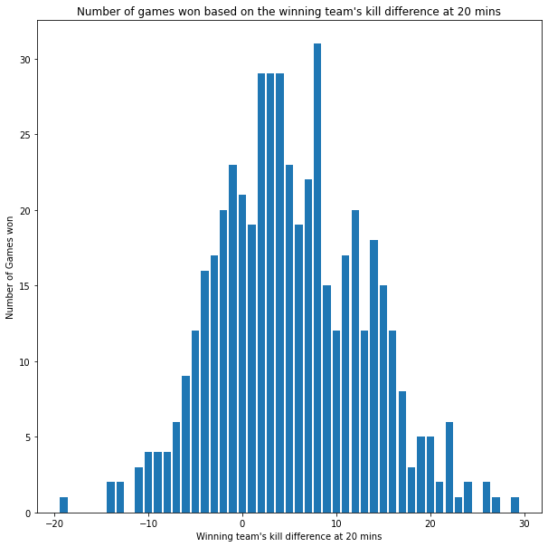

```python
abs_diff = []
diffs = []
for gam in master_list:
    a = gam.tdf
    b = a[a['ms_time'] <= (20 * 60 *1000)] #20*60*1000 = number of milliseconds in 20 mins
    c = b[(b['Event_Code'] == 'CHAMPION_KILL')]
    blue_kills = len(c[c['Actor_Team'] == 'Blue Team'])
    red_kills = len(c[c['Actor_Team'] == 'Red Team'])
    blue_won = gam.blue_team.won
    if(blue_won):
        diff = blue_kills - red_kills
    else:
        diff = red_kills - blue_kills
    abs_diff.append(abs(diff))
    diffs.append(diff)
unique_diffs = np.unique(np.array(diffs))
c = []
unique_abs_diffs = np.unique(np.array(abs_diff))
a_c = []
for d in unique_diffs:
    c.append(diffs.count(d))
for a_d in unique_abs_diffs:
    a_c.append(abs_diff.count(a_d))
plt.figure(0)
plt.figure(figsize=(10,10))
plt.bar(unique_diffs, c)
plt.xlabel('Winning team\'s kill difference at 20 mins')
plt.ylabel('Number of Games won')
plt.title('Number of games won based on the winning team\'s kill difference at 20 mins')
plt.show
```

Now, let's examine the actual winrate versus kill difference at 20 mins. This is a bit complicated, as we are looking at stats before the outcome of the game is determined. We are looking at **one team's** chance of doing x and eventually winning, but a game has two teams. If a team has a kill difference of 5 and wins, the other team will have a kill difference of -5 and loses. This is important because a team's kill difference is not equivalent to a win/loss for that team. A team with a negative kill difference can still win, and a team with a positivie kill difference can still lose.

The data from the graph above shows us how many teams eventually win with x kill difference, but to get the chance of winning under these circumstances, we need to divide it by the total number of teams with those circumstances. This will be the number of games with |x| = x kill difference.

$$ \frac{w} {\left(w + l\right)} $$

Where

- w = the number of **TEAMS** who won while 1 kill ahead at 20 mins
- l = the number of **TEAMS** who lost while 1 kill ahead at 20 mins

Which is equivalent to $$ \frac{w}{|g|} $$

Where

- |g| = the number of **GAMES** with a kill difference of +/- 1

```
<function matplotlib.pyplot.show(close=None, block=None)>
```

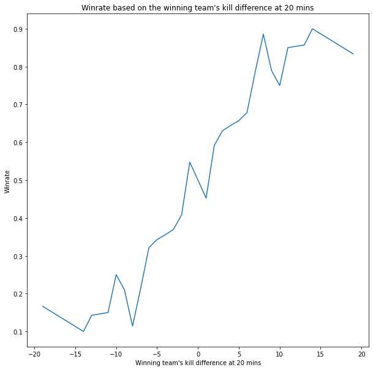

```python
##Make a dictionary that maps the unique difference values and the number of times they occur
diff_dict = {unique_diffs[i] : c[i] for i in range(len(c))}
##Make a dictionary that maps the unique absolute difference values and the number of tiems they occur
abs_dict = {unique_abs_diffs[i] : a_c[i] for i in range(len(a_c))}
wr = []
used_diffs = []
for d in unique_diffs:##go through our list of unique kill diffs and calculate a winrate
    if (d == 0):
        used_diffs.append(d)
        wr.append(.5) #Can assume 50/50 odds for teams with no kill difference
        continue
    if (d*-1) in unique_diffs:
        used_diffs.append(d)
        wr.append(diff_dict[d] / abs_dict[abs(d)])
plt.figure(1)
plt.figure(figsize=(10,10))
plt.plot(used_diffs, wr)
plt.xlabel('Winning team\'s kill difference at 20 mins')
plt.ylabel('Winrate')
plt.title('Winrate based on the winning team\'s kill difference at 20 mins')
plt.show
```

```
<function matplotlib.pyplot.show(close=None, block=None)>
```

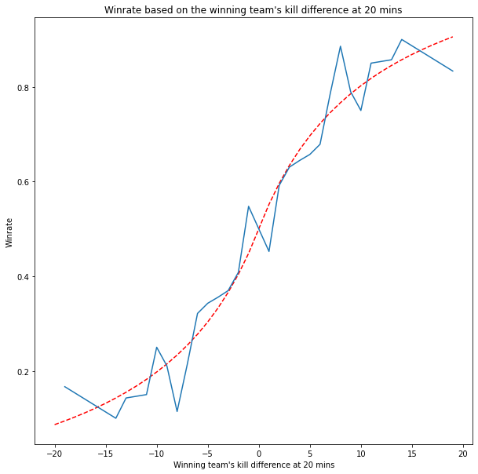

```python
##This is a function which represents the polynomial we are trying to perfect in order to get a model for our data
def poly(x, a, b, c):
    ret = []
    for i in x:
        ret.append(((a*i) / (math.sqrt(i**2) + b) + c))
    return ret
##Here, we are using the scipy library to adjust our coefficients a,b,and c, then storing the final values
ret, _ = scip.curve_fit(poly, used_diffs, wr)
a, b, c = ret
##We want to plot our model wto see how accurate it is. We are generating a new list of x models ranging from the smallest
##x value we used in our plot from earlier to the largest x value we used
new_x = np.arange(min(used_diffs) - 1, max(used_diffs)+1, 1)
##Calculate new y values with our shiny new polynomial and our new x values
new_y = poly(new_x, a, b, c)
plt.figure(2)
plt.figure(figsize=(10,10))
plt.plot(new_x, new_y, '--', color='red')
plt.plot(used_diffs, wr)
plt.xlabel('Winning team\'s kill difference at 20 mins')
plt.ylabel('Winrate')
plt.title('Winrate based on the winning team\'s kill difference at 20 mins')
plt.show
```

```python
print('a = %.2f, b = %.2f, c = %.2f for' % (a, b, c))
```

```
a = 0.65, b = 11.63, c = 0.50 for
```

### A single lane's effect on the outcome of a game

Another condition that people claim makes a game unwinnable is when one lane is ahead, even if it is just one enemy player that's ahead out of the 5, they will call for a surrender vote. The phrase "Top gap" comes to mind (which refers to a gap in skill between the two top laners which caused the loss/win). To see how righteous this claim is, I will analyze the number of games won when each lane is ahead by x kills over time.

See Below the graphs for analysis and explanation

```python
##This is a helper function that maps all of the potential keys in the keys list to their corresponding value in dictionary
##d. This returns a list of those values
def val_list(d, keys):
    ret = []
    for k in keys:
        ret.append(d[k])
    return ret
```

```python
##Another helper function used in analyzing the event dataframes. In order to filter a dataframe based on a column, you
##need a function that takes a column and returns a boolean column of the same length. This one just happens to check
## if a certain player assisted in any of the rowas of column assist_list (a list of player lists)
def did_player_assist(assist_list, player):
    ret = []
    for assists in assist_list:
        ret.append(player in assists)
    return ret
```

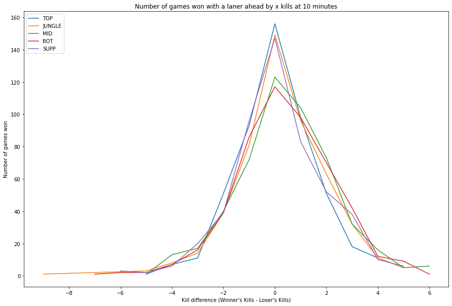

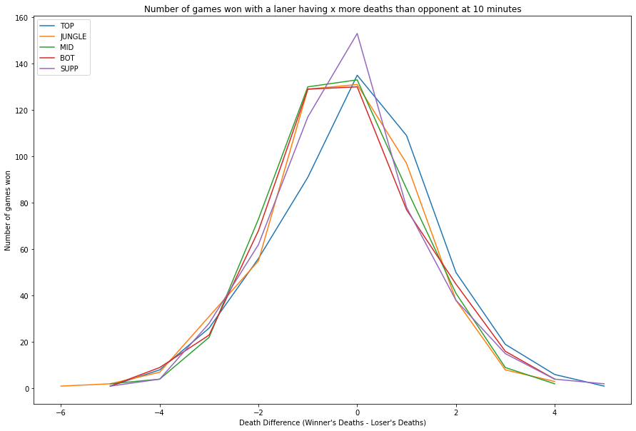

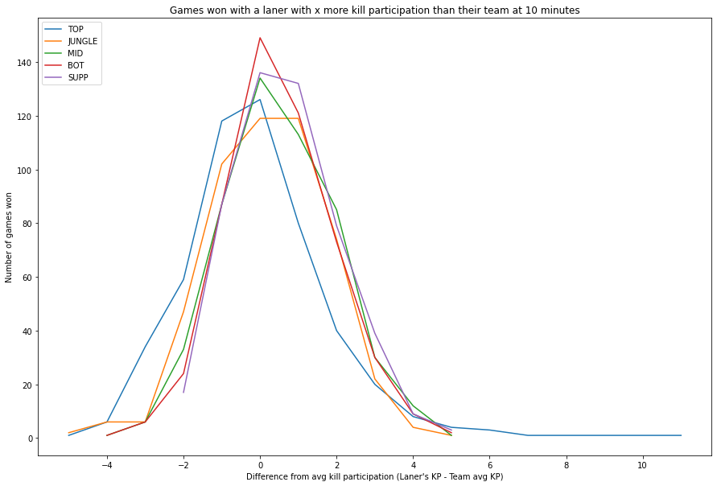

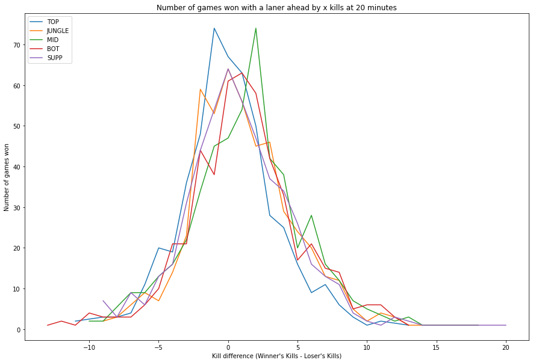

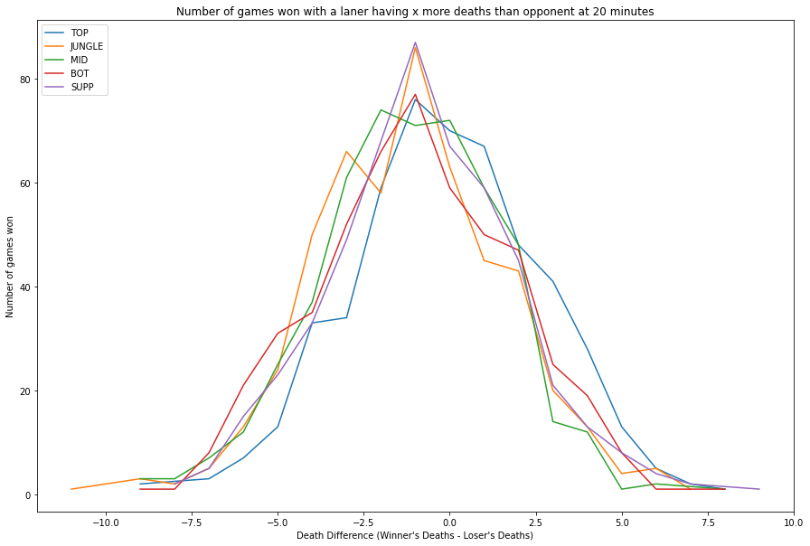

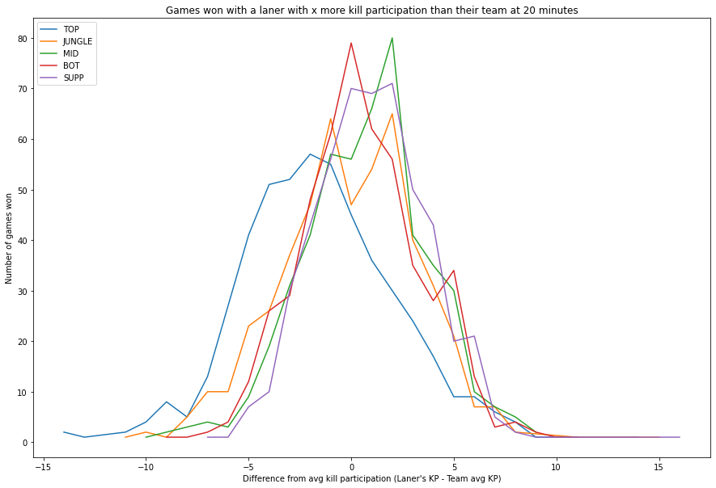

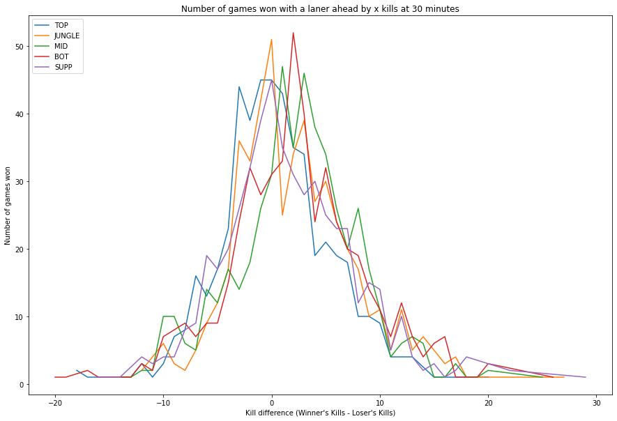

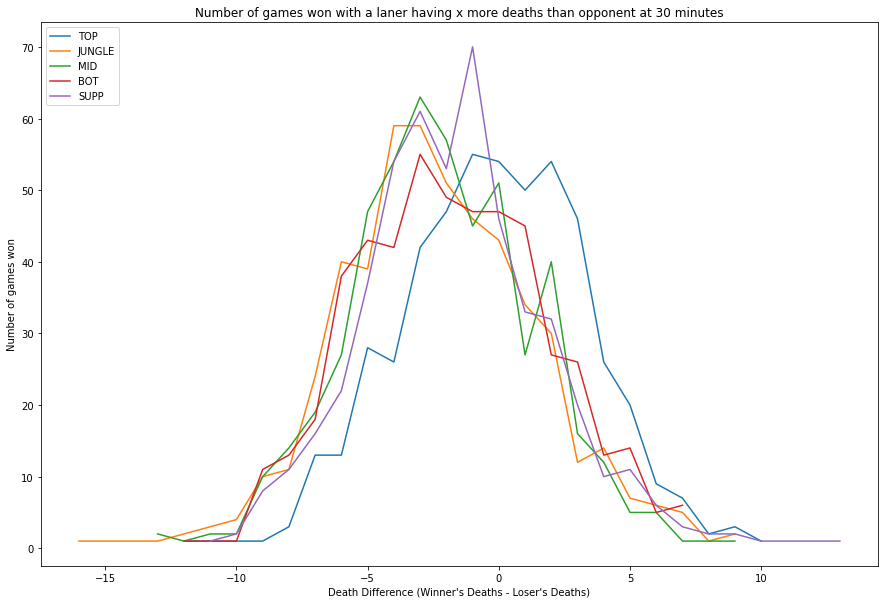

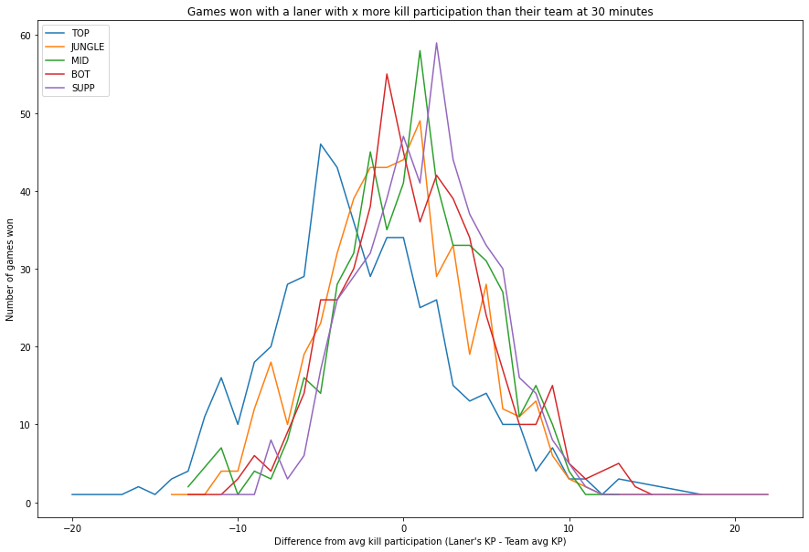

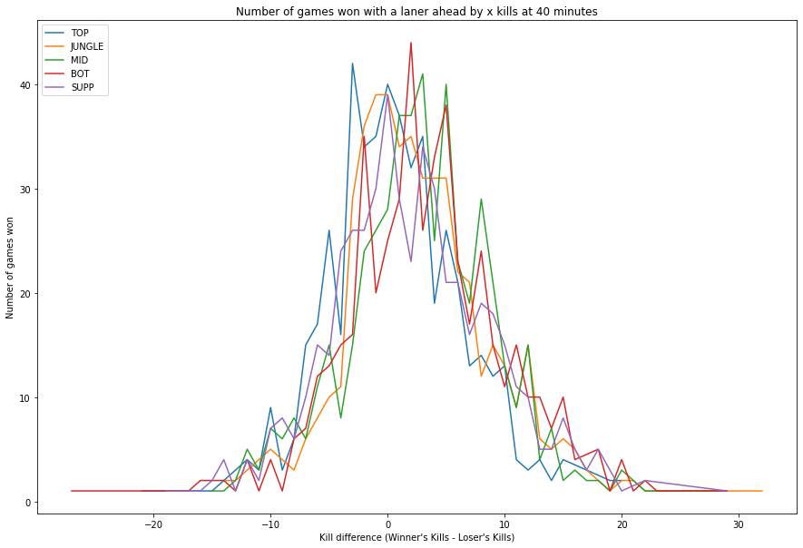

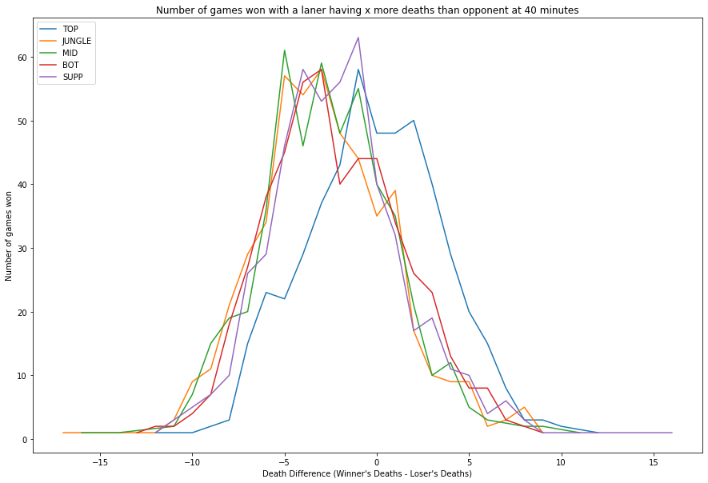

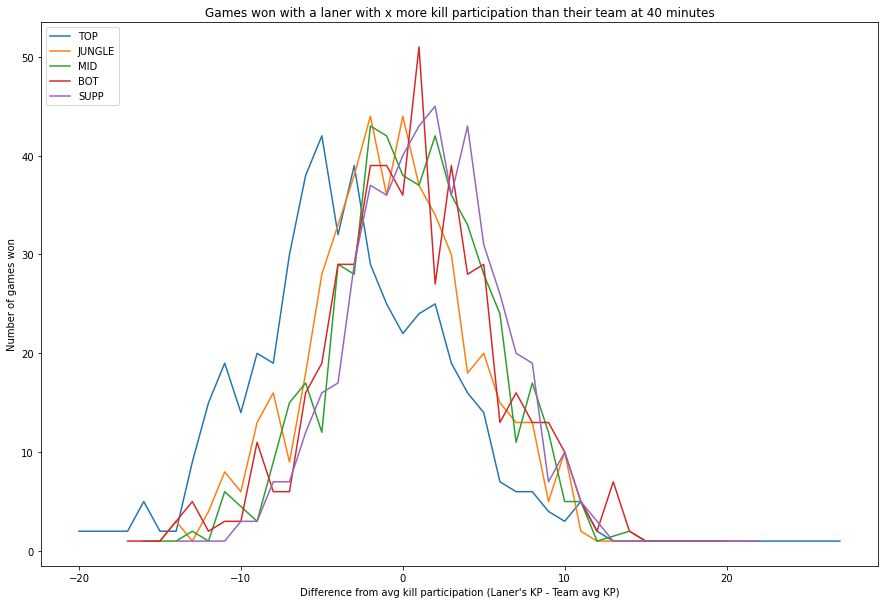

```python
lane_dictionaries = {
    1 : {},
    2 : {},
    3 : {},
    4 : {},
    5 : {}
}

for t in [10, 20, 30, 40]:
    for i in [1,2,3,4,5]:
        lane_dictionaries[i]['kills'] = {}
        lane_dictionaries[i]['deaths'] = {}
        lane_dictionaries[i]['part'] = {}
    #reset the timeframe's dictionaries

    #For each lane, count kill, death, and kill participation difference
    for gam in master_list:
        a = gam.tdf #timeline dataframe
        b = a[a['Event_Code'] == 'CHAMPION_KILL']
        c = b[b['ms_time'] <= (t*60*1000)] #t*60*1000 is the number of milliseconds in t mins
        #counting the number of kills, deaths, and deviation from average team kill participation made by each player at time t

        for i in range(1, 6):
            k_d = len(c[c['Event_Actor'] == i]) - len(c[c['Event_Actor'] == (4+i)])
            d_d = len(c[c['Event_Subject'] == i]) - len(c[c['Event_Subject'] == (4+i)])

            if gam.red_team.won:
                k_d = -1*k_d
                d_d = -1*d_d
                k_p = len(c[c['Event_Actor'] == i+4]) + len(c[did_player_assist(c['Assisters'], i+4)])
                team_total_participation = 0
                for j in [6, 7, 8, 9, 10]:
                    team_total_participation += len(c[c['Event_Actor'] == j]) + len(c[did_player_assist(c['Assisters'], j)])
                avg_p = int(team_total_participation / 5)
                k_p -= avg_p
            else:
                k_p = len(c[c['Event_Actor'] == i]) + len(c[did_player_assist(c['Assisters'], i)])
                team_total_participation = 0
                for j in [1,2,3,4,5]:
                    team_total_participation += len(c[c['Event_Actor'] == j]) + len(c[did_player_assist(c['Assisters'], j)])
                avg_p = int(team_total_participation / 5)
                k_p -= avg_p
            try:
                (lane_dictionaries[i])['kills'][k_d] += 1
            except(KeyError):
                (lane_dictionaries[i])['kills'][k_d] = 1
            try:
                (lane_dictionaries[i])['deaths'][d_d] +=1
            except(KeyError):
                (lane_dictionaries[i])['deaths'][d_d] = 1
            try:
                (lane_dictionaries[i])['part'][k_p] += 1
            except(KeyError):
                (lane_dictionaries[i])['part'][k_p] = 1


    plt.figure(figsize=(15,10))
    labels = ['null', 'TOP', 'JUNGLE', 'MID', 'BOT', 'SUPP']
    for i in [1,2,3,4,5]:
        cur_dictionary = lane_dictionaries[i]['kills']
        x = list(cur_dictionary.keys())
        x.sort()
        plt.plot(x, val_list(cur_dictionary, x), label=labels[i])
    plt.legend(loc='upper left')
    plt.xlabel('Kill difference (Winner\'s Kills - Loser\'s Kills)')
    plt.ylabel('Number of games won')
    plt.title('Number of games won with a laner ahead by x kills at ' + str(t) + ' minutes')
    plt.show()

    plt.figure(figsize=(15,10))
    for i in [1,2,3,4,5]:
        cur_dictionary = lane_dictionaries[i]['deaths']
        x = list(cur_dictionary.keys())
        x.sort()
        plt.plot(x, val_list(cur_dictionary, x), label=labels[i])
    plt.legend(loc='upper left')
    plt.xlabel('Death Difference (Winner\'s Deaths - Loser\'s Deaths)')
    plt.ylabel('Number of games won')
    plt.title('Number of games won with a laner having x more deaths than opponent at ' + str(t) + ' minutes')
    plt.show()

    plt.figure(figsize=(15,10))
    for i in [1,2,3,4,5]:
        cur_dictionary = lane_dictionaries[i]['part']
        x = list(cur_dictionary.keys())
        x.sort()
        plt.plot(x, val_list(cur_dictionary, x), label=labels[i])
    plt.legend(loc='upper left')
    plt.xlabel('Difference from avg kill participation (Laner\'s KP - Team avg KP)')
    plt.ylabel('Number of games won')
    plt.title('Games won with a laner with x more kill participation than their team at ' + str(t) + ' minutes')
    plt.show()
```

Okay, that was a lot of graphs, but bear with me. There are groups of three graphs at a time. Each group is seperated by 10 minutes.

- The first graph in a group shows the number of games won when a laner (distinguished by their line color) is ahead by x kills at t minutes (specefied in the title of the graph). This was done to see if any one laner could get away with a higher winrate than other lanes even if they lose to their opponent (in kills). For example If bot lane's graph is abve the rest of the lanes' graphs when the kill difference is negative, we could conclude that bot lane would not have as much of an impact on the outcome of the game as they lost more than the other lanes, but still won the game.
- The second graph in a set shows the number of games won when a laner has x more deaths than their lane opponent at time t. This was done because a laner may benefit their own team by having more kills than their opponent, but that benefit may be overshadowed if that laner died more times to the enemy team. For example, in a game, the two junglers may have the scores 4/10/~ and 1/1/~ (in K/D/A format). If we look at the first graph (which only counts kills), we may think that the first jungler is benefitting their team more than the second jungler. However, considering the deaths of both junglers, the first jungler would have benefitted the enemy team by dying to them more often than he benefitted his own team by getting kills. In other words, the second jungler is obviously doing better. If a lane's graph falls above the other lanes' graphs when the death difference is positive, then it could be reasoned that the lane would be able to die more yet win more than the other lanes with the same death disparities.
- The last graph shows how many games are won when a laner has x more participation in their team's kills than **Their Team's** average kill participation at time t. Kill participation is defined as the fraction number of kills that you participated in over the number of kills your team has. For instance, if your team has 4 kills total, and you only have 1, your kill participation would be 1/4. This was done to see if a team could lose more due to a single lane's bad performance. If a lane is not participating in the fights with the rest of the team, will that affect the outcome of the game?

**When in doubt, just look at the title of the graph and it should be self-explanatory**

#### 10 Minutes

Here, there wasn't much surprise. 10 minutes into the game is still considered the early game, so there is a lot of time for a team to fix any errors in the remainder of the game. Every lane's pull on the outcome of the game appears to be equal for the most part

#### 40 Minutes

There isn't much change between the 30 minute graphs and the 40 minute graphs. They show the same general trends I have been discussing for the other timeframes. This is most likely because fewer games last for 40 minutes than 30 minutes. If a game ends before 40 minutes, the statistics of the players won't change anymore to affect the outcome of the game, so the graphs will remain where they were at the last threshold. There will still be some minor changes from the few games that last to 40 the 40 minute mark and beyond

**Does top lane have to do well to win?** Why are the graphs showing that top lane can die more and participate in fights less and still win? I would have to crunch some more data, but if I had to guess, I would say that this discrepancy is due to common strategies with top laners. In many games, top laners are encouraged to avoid highly-contested areas of the map in favor of 'split pushing' or constantly threatening structures far away from a contested area to draw attention away from their team. For instance, if both teams are sending most of their players to the bottom side of the map to compete for a resource, one team may send their top laner to the opposite side of the map to threaten a turret or other enemy structure there. This forces the enemy team into a dilemma. Will they leave the hot zone to defend their base but give up the resource? Or will they stay and fight for the resource, but lose portions of their base to the split pushing top laner?

This would explain the excess of deaths and the lack of kill participation. If the top laner is away from the hot zone, they won't participate in any kills made there, but if the enemy team elects to defend their base, the top laner would often die during the defense, but his team would benefit from obtaining the resource that the enemy team gave up to defend their base.

I will save this analysis for another time.

## Conclusion

I entered this project aiming to find out if people were justified in claiming that a game was unwinnable under certain circumstances in the early game. I found that for many of the common 'unwinnable conditions', the winrate for both teams was high enough to warrant continued effort.

- **First Blood** ~55/45 % advantage
- **First Dragon** ~60/40 % advantage
- **First Tower** ~60/40% advantage
- **First Herald** ~60/40% advantage
- **First Mythic Item** ~60/40% advantage
- **First Baron** ~80/20% advantage (All calculated over 500 randomly sampled games)

In other words, most of these unwinnable conditions **Are more winnable than people expect**

I also looked at the effects of changing kill difference between teams at 20 minutes on winrate. As it turns out, the state of the game at 20 minutes often does determine the outcome of the game. It appears that after a kill defecit of 10, your winrate is down to about 20%, and gets worse from there. At this point, the justification for an 'unwinnable game' based on the score is going to depend on how optimistic you are about low winrates. If your expected chance of winning is 20% at a certain point in the game, are you willing to put forth the effort to win 1/5 of the games with those conditions? For me, the answer is always yes. I don't expect, nor would I tell people to expect to win under those circumstances, but if you're playing a large number of games in a ranked setting for the purposes of climbing the ranked ladder, taking those 1/5 games will slowly add up over time, and hypothetically your rank should be higher than if you threw those chances away. Something about the law of gross numbers and some-such.

If you disagree with any of the observations I made, that's great! I'm not perfect, but I've also shown you the tools necessary to gather enough data (or the same data) to dispute any of my claims. If this notebook is successful, hopefully you will know *how* to use them too :)